# Introduction to R/Jupyter

      3. 'H'

      4. 'T'

      2. 'T'

      3. 'H'

      4. 'T'

      2. 'T'

      3. 'H'

      4. 'H'

      2. 'T'

      3. 'H'

      4. 'H'

9364. 1. 'H'

      2. 'T'

      3. 'T'

      4. 'T'

9365. 1. 'H'

      2. 'T'

      3. 'H'

      4. 'H'

9366. 1. 'T'

      2. 'T'

      3. 'T'

      4. 'H'

9367. 1. 'T'

      2. 'H'

      3. 'H'

      4. 'H'

9368. 1. 'T'

      2. 'T'

      3. 'T'

      4. 'H'

9369. 1. 'T'

      2. 'H'

      3. 'T'

      4. 'H'

9370. 1. 'H'

      2. 'T'

      3. 'T'

      4. 'H'

9371. 1. 'H'

      2. 'T'

      3. 'H'

      4. 'H'

9372. 1. 'H'

      2. 'T'

      3. 'H'

      4. 'T'

9373. 1. 'T'

      2. 'T'

      3. 'T'

      4. 'H'

9374. 1. 'T'

      2. 'H'

      3. 'H'

      4. 'H'

9375. 1. 'H'

      2. 'T'

      3. 'T'

      4. 'T'

9376. 1. 'T'

      2. 'T'

      3. 'T'

      4. 'H'

9377. 1. 'T'

      2. 'T'

      3. 'H'

      4. 'T'

9378. 1. 'T'

      2. 'H'

      3. 'T'

      4. 'H'

9379. 1. 'T'

      2. 'T'

      3. 'T'

      4. 'H'

9380. 1. 'H'

      2. 'T'

      3. 'H'

      4. 'T'

9381. 1. 'H'

      2. 'H'

      3. 'H'

      4. 'T'

9382. 1. 'H'

      2. 'H'

      3. 'T'

      4. 'H'

9383. 1. 'T'

      2. 'H'

      3. 'T'

      4. 'T'

9384. 1. 'H'

      2. 'H'

      3. 'T'

      4. 'T'

9385. 1. 'T'

      2. 'H'

      3. 'H'

      4. 'T'

9386. 1. 'T'

      2. 'T'

      3. 'H'

      4. 'T'

9387. 1. 'T'

      2. 'H'

      3. 'H'

      4. 'T'

9388. 1. 'T'

      2. 'T'

      3. 'H'

      4. 'H'

9389. 1. 'T'

      2. 'H'

      3. 'H'

      4. 'T'

9390. 1. 'T'

      2. 'T'

      3. 'H'

      4. 'T'

9391. 1. 'H'

      2. 'H'

      3. 'T'

      4. 'T'

9392. 1. 'H'

      2. 'T'

      3. 'H'

      4. 'H'

9393. 1. 'H'

      2. 'T'

      3. 'T'

      4. 'H'

9394. 1. 'T'

      2. 'T'

      3. 'T'

      4. 'T'

9395. 1. 'H'

      2. 'H'

      3. 'T'

      4. 'H'

9396. 1. 'T'

      2. 'T'

      3. 'H'

      4. 'T'

9397. 1. 'T'

      2. 'H'

      3. 'H'

      4. 'T'

9398. 1. 'H'

      2. 'T'

      3. 'T'

      4. 'H'

9399. 1. 'T'

      2. 'T'

      3. 'T'

      4. 'T'

9400. 1. 'T'

      2. 'T'

      3. 'T'

      4. 'H'

9401. 1. 'T'

      2. 'T'

      3. 'T'

      4. 'H'

9402. 1. 'T'

      2. 'H'

      3. 'H'

      4. 'T'

9403. 1. 'H'

      2. 'H'

      3. 'H'

      4. 'H'

9404. 1. 'T'

      2. 'T'

      3. 'T'

      4. 'H'

9405. 1. 'H'

      2. 'T'

      3. 'H'

      4. 'T'

9406. 1. 'H'

      2. 'H'

      3. 'H'

      4. 'H'

9407. 1. 'T'

      2. 'H'

      3. 'H'

      4. 'T'

9408. 1. 'T'

      2. 'H'

      3. 'H'

      4. 'T'

9409. 1. 'H'

      2. 'T'

      3. 'H'

      4. 'H'

9410. 1. 'H'

      2. 'T'

      3. 'T'

      4. 'H'

9411. 1. 'T'

      2. 'T'

      3. 'T'

      4. 'T'

9412. 1. 'T'

      2. 'T'

      3. 'H'

      4. 'T'

9413. 1. 'H'

      2. 'H'

      3. 'T'

      4. 'T'

9414. 1. 'T'

      2. 'T'

      3. 'T'

      4. 'T'

9415. 1. 'T'

      2. 'H'

      3. 'H'

      4. 'H'

9416. 1. 'H'

      2. 'H'

      3. 'H'

      4. 'T'

9417. 1. 'H'

      2. 'H'

      3. 'H'

      4. 'H'

9418. 1. 'T'

      2. 'H'

      3. 'H'

      4. 'T'

9419. 1. 'T'

      2. 'T'

      3. 'T'

      4. 'T'

9420. 1. 'H'

      2. 'H'

      3. 'T'

      4. 'T'

9421. 1. 'H'

      2. 'H'

      3. 'T'

      4. 'T'

9422. 1. 'T'

      2. 'T'

      3. 'H'

      4. 'T'

9423. 1. 'T'

      2. 'H'

      3. 'H'

      4. 'T'

9424. 1. 'T'

      2. 'H'

      3. 'T'

      4. 'T'

9425. 1. 'H'

      2. 'H'

      3. 'T'

      4. 'H'

9426. 1. 'T'

      2. 'T'

      3. 'T'

      4. 'H'

9427. 1. 'T'

      2. 'H'

      3. 'H'

      4. 'T'

9428. 1. 'H'

      2. 'T'

      3. 'T'

      4. 'H'

9429. 1. 'T'

      2. 'T'

      3. 'T'

      4. 'H'

9430. 1. 'H'

      2. 'H'

      3. 'T'

      4. 'H'

9431. 1. 'H'

      2. 'T'

      3. 'H'

      4. 'T'

9432. 1. 'H'

      2. 'H'

      3. 'T'

      4. 'H'

9433. 1. 'T'

      2. 'H'

      3. 'H'

      4. 'H'

9434. 1. 'H'

      2. 'H'

      3. 'H'

      4. 'T'

9435. 1. 'H'

      2. 'T'

      3. 'H'

      4. 'T'

9436. 1. 'T'

      2. 'H'

      3. 'T'

      4. 'T'

9437. 1. 'H'

      2. 'H'

      3. 'H'

      4. 'H'

9438. 1. 'T'

      2. 'H'

      3. 'T'

      4. 'H'

9439. 1. 'H'

      2. 'T'

      3. 'T'

      4. 'T'

9440. 1. 'H'

      2. 'T'

      3. 'T'

      4. 'H'

9441. 1. 'H'

      2. 'H'

      3. 'T'

      4. 'T'

9442. 1. 'T'

      2. 'T'

      3. 'T'

      4. 'T'

9443. 1. 'T'

      2. 'T'

      3. 'H'

      4. 'T'

9444. 1. 'T'

      2. 'T'

      3. 'H'

      4. 'H'

9445. 1. 'T'

      2. 'H'

      3. 'H'

      4. 'H'

9446. 1. 'H'

      2. 'H'

      3. 'H'

      4. 'T'

9447. 1. 'T'

      2. 'T'

      3. 'H'

      4. 'T'

9448. 1. 'T'

      2. 'T'

      3. 'H'

      4. 'H'

9449. 1. 'H'

      2. 'T'

      3. 'H'

      4. 'H'

9450. 1. 'T'

      2. 'T'

      3. 'H'

      4. 'T'

9451. 1. 'T'

      2. 'T'

      3. 'T'

      4. 'T'

9452. 1. 'T'

      2. 'T'

      3. 'T'

      4. 'H'

9453. 1. 'T'

      2. 'H'

      3. 'T'

      4. 'T'

9454. 1. 'T'

      2. 'H'

      3. 'T'

      4. 'H'

9455. 1. 'T'

      2. 'H'

      3. 'T'

      4. 'H'

9456. 1. 'T'

      2. 'T'

      3. 'H'

      4. 'T'

9457. 1. 'H'

      2. 'H'

      3. 'T'

      4. 'T'

9458. 1. 'T'

      2. 'H'

      3. 'T'

      4. 'T'

9459. 1. 'T'

      2. 'T'

      3. 'H'

      4. 'H'

9460. 1. 'H'

      2. 'T'

      3. 'H'

      4. 'T'

9461. 1. 'H'

      2. 'T'

      3. 'T'

      4. 'T'

9462. 1. 'T'

      2. 'H'

      3. 'T'

      4. 'H'

9463. 1. 'H'

      2. 'T'

      3. 'H'

      4. 'T'

9464. 1. 'T'

      2. 'H'

      3. 'H'

      4. 'T'

9465. 1. 'H'

      2. 'H'

      3. 'T'

      4. 'H'

9466. 1. 'T'

      2. 'H'

      3. 'H'

      4. 'T'

9467. 1. 'T'

      2. 'H'

      3. 'H'

      4. 'H'

9468. 1. 'T'

      2. 'H'

      3. 'H'

      4. 'T'

9469. 1. 'H'

      2. 'T'

      3. 'T'

      4. 'H'

9470. 1. 'T'

      2. 'T'

      3. 'T'

      4. 'T'

9471. 1. 'H'

      2. 'H'

      3. 'H'

      4. 'H'

9472. 1. 'H'

      2. 'T'

      3. 'T'

      4. 'H'

9473. 1. 'T'

      2. 'T'

      3. 'H'

      4. 'T'

9474. 1. 'H'

      2. 'T'

      3. 'T'

      4. 'T'

9475. 1. 'H'

      2. 'T'

      3. 'T'

      4. 'T'

9476. 1. 'T'

      2. 'H'

      3. 'H'

      4. 'H'

9477. 1. 'T'

      2. 'T'

      3. 'T'

      4. 'T'

9478. 1. 'T'

      2. 'T'

      3. 'T'

      4. 'T'

9479. 1. 'T'

      2. 'T'

      3. 'T'

      4. 'T'

9480. 1. 'T'

      2. 'H'

      3. 'H'

      4. 'T'

9481. 1. 'T'

      2. 'H'

      3. 'H'

      4. 'H'

9482. 1. 'H'

      2. 'H'

      3. 'T'

      4. 'T'

9483. 1. 'H'

      2. 'H'

      3. 'T'

      4. 'H'

9484. 1. 'T'

      2. 'T'

      3. 'H'

      4. 'H'

9485. 1. 'T'

      2. 'H'

      3. 'T'

      4. 'H'

9486. 1. 'T'

      2. 'T'

      3. 'T'

      4. 'T'

9487. 1. 'T'

      2. 'H'

      3. 'T'

      4. 'H'

9488. 1. 'H'

      2. 'T'

      3. 'T'

      4. 'H'

9489. 1. 'T'

      2. 'H'

      3. 'H'

      4. 'T'

9490. 1. 'H'

      2. 'T'

      3. 'T'

      4. 'T'

9491. 1. 'H'

      2. 'H'

      3. 'H'

      4. 'H'

9492. 1. 'T'

      2. 'T'

      3. 'T'

      4. 'H'

9493. 1. 'T'

      2. 'T'

      3. 'H'

      4. 'H'

9494. 1. 'H'

      2. 'T'

      3. 'H'

      4. 'H'

9495. 1. 'H'

      2. 'H'

      3. 'H'

      4. 'T'

9496. 1. 'T'

      2. 'T'

      3. 'H'

      4. 'T'

9497. 1. 'H'

      2. 'H'

      3. 'T'

      4. 'H'

9498. 1. 'T'

      2. 'T'

      3. 'T'

      4. 'H'

9499. 1. 'T'

      2. 'H'

      3. 'H'

      4. 'H'

9500. 1. 'T'

      2. 'T'

      3. 'H'

      4. 'T'

9501. 1. 'H'

      2. 'H'

      3. 'H'

      4. 'T'

9502. 1. 'H'

      2. 'T'

      3. 'H'

      4. 'H'

9503. 1. 'T'

      2. 'T'

      3. 'T'

      4. 'T'

9504. 1. 'T'

      2. 'H'

      3. 'H'

      4. 'H'

9505. 1. 'T'

      2. 'T'

      3. 'H'

      4. 'T'

9506. 1. 'T'

      2. 'T'

      3. 'T'

      4. 'H'

9507. 1. 'T'

      2. 'T'

      3. 'T'

      4. 'H'

9508. 1. 'H'

      2. 'T'

      3. 'T'

      4. 'H'

9509. 1. 'H'

      2. 'T'

      3. 'T'

      4. 'H'

9510. 1. 'T'

      2. 'H'

      3. 'H'

      4. 'T'

9511. 1. 'T'

      2. 'H'

      3. 'H'

      4. 'T'

9512. 1. 'T'

      2. 'T'

      3. 'T'

      4. 'T'

9513. 1. 'T'

      2. 'T'

      3. 'H'

      4. 'H'

9514. 1. 'H'

      2. 'T'

      3. 'T'

      4. 'T'

9515. 1. 'T'

      2. 'T'

      3. 'T'

      4. 'H'

9516. 1. 'T'

      2. 'T'

      3. 'T'

      4. 'T'

9517. 1. 'H'

      2. 'T'

      3. 'T'

      4. 'T'

9518. 1. 'H'

      2. 'T'

      3. 'T'

      4. 'T'

9519. 1. 'T'

      2. 'T'

      3. 'T'

      4. 'H'

9520. 1. 'H'

      2. 'T'

      3. 'H'

      4. 'H'

9521. 1. 'T'

      2. 'H'

      3. 'T'

      4. 'H'

9522. 1. 'T'

      2. 'T'

      3. 'H'

      4. 'H'

9523. 1. 'H'

      2. 'T'

      3. 'H'

      4. 'T'

9524. 1. 'H'

      2. 'H'

      3. 'H'

      4. 'H'

9525. 1. 'T'

      2. 'T'

      3. 'T'

      4. 'H'

9526. 1. 'H'

      2. 'H'

      3. 'T'

      4. 'H'

9527. 1. 'T'

      2. 'H'

      3. 'T'

      4. 'H'

9528. 1. 'T'

      2. 'T'

      3. 'H'

      4. 'T'

9529. 1. 'T'

      2. 'T'

      3. 'H'

      4. 'H'

9530. 1. 'T'

      2. 'T'

      3. 'T'

      4. 'H'

9531. 1. 'H'

      2. 'T'

      3. 'H'

      4. 'H'

9532. 1. 'H'

      2. 'H'

      3. 'T'

      4. 'T'

9533. 1. 'T'

      2. 'H'

      3. 'H'

      4. 'T'

9534. 1. 'T'

      2. 'H'

      3. 'T'

      4. 'H'

9535. 1. 'H'

      2. 'H'

      3. 'T'

      4. 'H'

9536. 1. 'H'

      2. 'H'

      3. 'T'

      4. 'T'

9537. 1. 'H'

      2. 'T'

      3. 'T'

      4. 'T'

9538. 1. 'T'

      2. 'T'

      3. 'H'

      4. 'H'

9539. 1. 'H'

      2. 'H'

      3. 'T'

      4. 'H'

9540. 1. 'T'

      2. 'H'

      3. 'H'

      4. 'H'

9541. 1. 'H'

      2. 'H'

      3. 'H'

      4. 'T'

9542. 1. 'H'

      2. 'T'

      3. 'T'

      4. 'H'

9543. 1. 'T'

      2. 'T'

      3. 'H'

      4. 'H'

9544. 1. 'T'

      2. 'H'

      3. 'H'

      4. 'T'

9545. 1. 'H'

      2. 'H'

      3. 'T'

      4. 'H'

9546. 1. 'T'

      2. 'H'

      3. 'H'

      4. 'T'

9547. 1. 'H'

      2. 'H'

      3. 'H'

      4. 'T'

9548. 1. 'T'

      2. 'T'

      3. 'H'

      4. 'H'

9549. 1. 'H'

      2. 'T'

      3. 'H'

      4. 'T'

9550. 1. 'H'

      2. 'H'

      3. 'H'

      4. 'H'

9551. 1. 'H'

      2. 'T'

      3. 'T'

      4. 'H'

9552. 1. 'T'

      2. 'H'

      3. 'T'

      4. 'H'

9553. 1. 'H'

      2. 'T'

      3. 'T'

      4. 'T'

9554. 1. 'T'

      2. 'H'

      3. 'H'

      4. 'H'

9555. 1. 'H'

      2. 'T'

      3. 'T'

      4. 'H'

9556. 1. 'T'

      2. 'H'

      3. 'H'

      4. 'T'

9557. 1. 'T'

      2. 'T'

      3. 'T'

      4. 'T'

9558. 1. 'T'

      2. 'T'

      3. 'H'

      4. 'H'

9559. 1. 'T'

      2. 'H'

      3. 'H'

      4. 'H'

9560. 1. 'T'

      2. 'H'

      3. 'T'

      4. 'H'

9561. 1. 'T'

      2. 'T'

      3. 'T'

      4. 'T'

9562. 1. 'H'

      2. 'T'

      3. 'H'

      4. 'T'

9563. 1. 'H'

      2. 'H'

      3. 'T'

      4. 'H'

9564. 1. 'H'

      2. 'T'

      3. 'T'

      4. 'T'

9565. 1. 'T'

      2. 'T'

      3. 'H'

      4. 'H'

9566. 1. 'T'

      2. 'H'

      3. 'T'

      4. 'H'

9567. 1. 'T'

      2. 'T'

      3. 'H'

      4. 'T'

9568. 1. 'H'

      2. 'H'

      3. 'T'

      4. 'T'

9569. 1. 'H'

      2. 'H'

      3. 'H'

      4. 'T'

9570. 1. 'T'

      2. 'T'

      3. 'H'

      4. 'T'

9571. 1. 'H'

      2. 'T'

      3. 'T'

      4. 'H'

9572. 1. 'T'

      2. 'T'

      3. 'H'

      4. 'T'

9573. 1. 'H'

      2. 'H'

      3. 'H'

      4. 'H'

9574. 1. 'T'

      2. 'T'

      3. 'T'

      4. 'H'

9575. 1. 'H'

      2. 'H'

      3. 'H'

      4. 'H'

9576. 1. 'T'

      2. 'T'

      3. 'H'

      4. 'T'

9577. 1. 'H'

      2. 'H'

      3. 'T'

      4. 'H'

9578. 1. 'H'

      2. 'H'

      3. 'H'

      4. 'T'

9579. 1. 'H'

      2. 'T'

      3. 'T'

      4. 'H'

9580. 1. 'T'

      2. 'H'

      3. 'T'

      4. 'H'

9581. 1. 'T'

      2. 'H'

      3. 'H'

      4. 'H'

9582. 1. 'T'

      2. 'H'

      3. 'H'

      4. 'H'

9583. 1. 'H'

      2. 'H'

      3. 'T'

      4. 'H'

9584. 1. 'T'

      2. 'T'

      3. 'H'

      4. 'T'

9585. 1. 'H'

      2. 'H'

      3. 'H'

      4. 'T'

9586. 1. 'T'

      2. 'T'

      3. 'H'

      4. 'T'

9587. 1. 'H'

      2. 'H'

      3. 'H'

      4. 'T'

9588. 1. 'H'

      2. 'H'

      3. 'T'

      4. 'T'

9589. 1. 'T'

      2. 'H'

      3. 'T'

      4. 'T'

9590. 1. 'T'

      2. 'T'

      3. 'T'

      4. 'T'

9591. 1. 'T'

      2. 'T'

      3. 'T'

      4. 'H'

9592. 1. 'H'

      2. 'T'

      3. 'H'

      4. 'H'

9593. 1. 'T'

      2. 'H'

      3. 'T'

      4. 'T'

9594. 1. 'T'

      2. 'H'

      3. 'T'

      4. 'H'

9595. 1. 'T'

      2. 'T'

      3. 'H'

      4. 'H'

9596. 1. 'T'

      2. 'T'

      3. 'H'

      4. 'T'

9597. 1. 'T'

      2. 'T'

      3. 'H'

      4. 'T'

9598. 1. 'T'

      2. 'T'

      3. 'H'

      4. 'T'

9599. 1. 'H'

      2. 'T'

      3. 'H'

      4. 'H'

9600. 1. 'H'

      2. 'H'

      3. 'T'

      4. 'H'

9601. 1. 'H'

      2. 'T'

      3. 'H'

      4. 'H'

9602. 1. 'T'

      2. 'T'

      3. 'H'

      4. 'H'

9603. 1. 'H'

      2. 'H'

      3. 'T'

      4. 'H'

9604. 1. 'H'

      2. 'T'

      3. 'H'

      4. 'H'

9605. 1. 'T'

      2. 'H'

      3. 'H'

      4. 'T'

9606. 1. 'H'

      2. 'T'

      3. 'T'

      4. 'H'

9607. 1. 'T'

      2. 'T'

      3. 'H'

      4. 'H'

9608. 1. 'T'

      2. 'T'

      3. 'T'

      4. 'H'

9609. 1. 'T'

      2. 'T'

      3. 'T'

      4. 'H'

      2. 'T'

      3. 'H'

      4. 'T'

9611. 1. 'H'

      2. 'H'

      3. 'T'

      4. 'H'

9612. 1. 'H'

      2. 'H'

      3. 'H'

      4. 'T'

9613. 1. 'T'

      2. 'H'

      3. 'H'

      4. 'H'

9614. 1. 'T'

      2. 'T'

      3. 'H'

      4. 'T'

9615. 1. 'T'

      2. 'H'

      3. 'H'

      4. 'H'

9616. 1. 'H'

      2. 'T'

      3. 'T'

      4. 'H'

9617. 1. 'H'

      2. 'H'

      3. 'H'

      4. 'T'

9618. 1. 'T'

      2. 'T'

      3. 'T'

      4. 'T'

9619. 1. 'T'

      2. 'H'

      3. 'H'

      4. 'T'

9620. 1. 'T'

      2. 'H'

      3. 'H'

      4. 'H'

9621. 1. 'H'

      2. 'T'

      3. 'H'

      4. 'H'

9622. 1. 'H'

      2. 'T'

      3. 'T'

      4. 'H'

9623. 1. 'T'

      2. 'T'

      3. 'H'

      4. 'H'

9624. 1. 'T'

      2. 'H'

      3. 'H'

      4. 'H'

9625. 1. 'T'

      2. 'T'

      3. 'T'

      4. 'H'

9626. 1. 'H'

      2. 'H'

      3. 'T'

      4. 'T'

9627. 1. 'H'

      2. 'T'

      3. 'H'

      4. 'T'

9628. 1. 'T'

      2. 'H'

      3. 'T'

      4. 'T'

9629. 1. 'H'

      2. 'T'

      3. 'T'

      4. 'H'

9630. 1. 'T'

      2. 'H'

      3. 'H'

      4. 'H'

9631. 1. 'T'

      2. 'T'

      3. 'H'

      4. 'H'

9632. 1. 'T'

      2. 'T'

      3. 'T'

      4. 'T'

9633. 1. 'H'

      2. 'T'

      3. 'H'

      4. 'T'

9634. 1. 'H'

      2. 'T'

      3. 'T'

      4. 'T'

9635. 1. 'T'

      2. 'T'

      3. 'H'

      4. 'T'

9636. 1. 'T'

      2. 'H'

      3. 'T'

      4. 'T'

9637. 1. 'T'

      2. 'T'

      3. 'H'

      4. 'T'

9638. 1. 'H'

      2. 'T'

      3. 'H'

      4. 'T'

9639. 1. 'T'

      2. 'H'

      3. 'T'

      4. 'T'

9640. 1. 'H'

      2. 'T'

      3. 'H'

      4. 'H'

9641. 1. 'T'

      2. 'T'

      3. 'T'

      4. 'T'

9642. 1. 'T'

      2. 'H'

      3. 'H'

      4. 'H'

9643. 1. 'T'

      2. 'H'

      3. 'T'

      4. 'T'

9644. 1. 'T'

      2. 'T'

      3. 'T'

      4. 'T'

9645. 1. 'H'

      2. 'T'

      3. 'T'

      4. 'H'

9646. 1. 'H'

      2. 'T'

      3. 'H'

      4. 'T'

9647. 1. 'T'

      2. 'T'

      3. 'H'

      4. 'H'

9648. 1. 'H'

      2. 'T'

      3. 'T'

      4. 'T'

9649. 1. 'T'

      2. 'H'

      3. 'T'

      4. 'T'

9650. 1. 'T'

      2. 'H'

      3. 'H'

      4. 'T'

9651. 1. 'T'

      2. 'T'

      3. 'T'

      4. 'T'

9652. 1. 'T'

      2. 'T'

      3. 'T'

      4. 'H'

9653. 1. 'T'

      2. 'H'

      3. 'T'

      4. 'T'

9654. 1. 'T'

      2. 'H'

      3. 'H'

      4. 'H'

9655. 1. 'T'

      2. 'T'

      3. 'T'

      4. 'T'

9656. 1. 'T'

      2. 'T'

      3. 'H'

      4. 'H'

9657. 1. 'T'

      2. 'T'

      3. 'H'

      4. 'T'

9658. 1. 'H'

      2. 'T'

      3. 'T'

      4. 'T'

9659. 1. 'T'

      2. 'T'

      3. 'H'

      4. 'H'

9660. 1. 'H'

      2. 'T'

      3. 'H'

      4. 'H'

9661. 1. 'H'

      2. 'T'

      3. 'H'

      4. 'H'

9662. 1. 'H'

      2. 'T'

      3. 'H'

      4. 'H'

9663. 1. 'H'

      2. 'T'

      3. 'T'

      4. 'H'

9664. 1. 'H'

      2. 'T'

      3. 'H'

      4. 'H'

9665. 1. 'H'

      2. 'T'

      3. 'T'

      4. 'H'

9666. 1. 'T'

      2. 'T'

      3. 'H'

      4. 'H'

9667. 1. 'H'

      2. 'T'

      3. 'T'

      4. 'H'

9668. 1. 'H'

      2. 'H'

      3. 'H'

      4. 'H'

9669. 1. 'T'

      2. 'T'

      3. 'H'

      4. 'H'

9670. 1. 'H'

      2. 'H'

      3. 'H'

      4. 'T'

9671. 1. 'T'

      2. 'T'

      3. 'T'

      4. 'T'

9672. 1. 'H'

      2. 'T'

      3. 'H'

      4. 'T'

9673. 1. 'H'

      2. 'T'

      3. 'H'

      4. 'T'

9674. 1. 'H'

      2. 'T'

      3. 'H'

      4. 'H'

9675. 1. 'T'

      2. 'T'

      3. 'H'

      4. 'T'

9676. 1. 'H'

      2. 'H'

      3. 'H'

      4. 'H'

9677. 1. 'H'

      2. 'T'

      3. 'T'

      4. 'T'

9678. 1. 'T'

      2. 'H'

      3. 'H'

      4. 'H'

9679. 1. 'H'

      2. 'T'

      3. 'T'

      4. 'T'

9680. 1. 'T'

      2. 'T'

      3. 'H'

      4. 'T'

9681. 1. 'H'

      2. 'T'

      3. 'H'

      4. 'T'

9682. 1. 'T'

      2. 'H'

      3. 'H'

      4. 'H'

9683. 1. 'T'

      2. 'H'

      3. 'H'

      4. 'T'

9684. 1. 'T'

      2. 'H'

      3. 'T'

      4. 'T'

9685. 1. 'H'

      2. 'H'

      3. 'H'

      4. 'H'

9686. 1. 'H'

      2. 'H'

      3. 'T'

      4. 'T'

9687. 1. 'T'

      2. 'T'

      3. 'H'

      4. 'H'

9688. 1. 'T'

      2. 'H'

      3. 'T'

      4. 'H'

9689. 1. 'H'

      2. 'H'

      3. 'H'

      4. 'H'

9690. 1. 'H'

      2. 'T'

      3. 'T'

      4. 'H'

9691. 1. 'H'

      2. 'H'

      3. 'T'

      4. 'H'

9692. 1. 'H'

      2. 'H'

      3. 'T'

      4. 'H'

9693. 1. 'H'

      2. 'H'

      3. 'H'

      4. 'T'

9694. 1. 'H'

      2. 'H'

      3. 'T'

      4. 'H'

9695. 1. 'T'

      2. 'H'

      3. 'T'

      4. 'H'

9696. 1. 'H'

      2. 'H'

      3. 'H'

      4. 'T'

9697. 1. 'H'

      2. 'T'

      3. 'H'

      4. 'T'

9698. 1. 'H'

      2. 'T'

      3. 'H'

      4. 'H'

9699. 1. 'T'

      2. 'H'

      3. 'H'

      4. 'T'

9700. 1. 'H'

      2. 'T'

      3. 'H'

      4. 'T'

9701. 1. 'T'

      2. 'H'

      3. 'H'

      4. 'T'

9702. 1. 'T'

      2. 'T'

      3. 'T'

      4. 'T'

9703. 1. 'H'

      2. 'T'

      3. 'T'

      4. 'H'

9704. 1. 'T'

      2. 'H'

      3. 'T'

      4. 'H'

9705. 1. 'H'

      2. 'T'

      3. 'H'

      4. 'H'

9706. 1. 'T'

      2. 'T'

      3. 'T'

      4. 'T'

9707. 1. 'T'

      2. 'T'

      3. 'T'

      4. 'T'

9708. 1. 'T'

      2. 'T'

      3. 'T'

      4. 'H'

9709. 1. 'T'

      2. 'H'

      3. 'T'

      4. 'H'

9710. 1. 'H'

      2. 'H'

      3. 'H'

      4. 'T'

9711. 1. 'T'

      2. 'H'

      3. 'T'

      4. 'H'

9712. 1. 'T'

      2. 'T'

      3. 'T'

      4. 'T'

9713. 1. 'T'

      2. 'T'

      3. 'H'

      4. 'T'

9714. 1. 'T'

      2. 'H'

      3. 'H'

      4. 'H'

9715. 1. 'T'

      2. 'H'

      3. 'H'

      4. 'H'

9716. 1. 'T'

      2. 'H'

      3. 'H'

      4. 'H'

9717. 1. 'H'

      2. 'H'

      3. 'T'

      4. 'H'

9718. 1. 'T'

      2. 'H'

      3. 'H'

      4. 'H'

9719. 1. 'H'

      2. 'T'

      3. 'T'

      4. 'H'

9720. 1. 'H'

      2. 'T'

      3. 'T'

      4. 'T'

9721. 1. 'H'

      2. 'T'

      3. 'T'

      4. 'T'

9722. 1. 'T'

      2. 'T'

      3. 'T'

      4. 'H'

9723. 1. 'H'

      2. 'H'

      3. 'T'

      4. 'T'

9724. 1. 'H'

      2. 'T'

      3. 'T'

      4. 'H'

9725. 1. 'H'

      2. 'H'

      3. 'H'

      4. 'H'

9726. 1. 'T'

      2. 'T'

      3. 'T'

      4. 'T'

9727. 1. 'T'

      2. 'H'

      3. 'T'

      4. 'T'

9728. 1. 'T'

      2. 'T'

      3. 'H'

      4. 'H'

9729. 1. 'T'

      2. 'H'

      3. 'H'

      4. 'H'

9730. 1. 'H'

      2. 'T'

      3. 'H'

      4. 'H'

9731. 1. 'H'

      2. 'T'

      3. 'H'

      4. 'T'

9732. 1. 'T'

      2. 'T'

      3. 'H'

      4. 'T'

9733. 1. 'T'

      2. 'H'

      3. 'H'

      4. 'H'

9734. 1. 'H'

      2. 'T'

      3. 'H'

      4. 'T'

9735. 1. 'H'

      2. 'T'

      3. 'T'

      4. 'T'

9736. 1. 'H'

      2. 'T'

      3. 'T'

      4. 'T'

9737. 1. 'H'

      2. 'H'

      3. 'T'

      4. 'H'

9738. 1. 'T'

      2. 'T'

      3. 'T'

      4. 'T'

9739. 1. 'H'

      2. 'H'

      3. 'T'

      4. 'T'

9740. 1. 'T'

      2. 'T'

      3. 'H'

      4. 'T'

9741. 1. 'H'

      2. 'T'

      3. 'H'

      4. 'H'

9742. 1. 'T'

      2. 'H'

      3. 'H'

      4. 'H'

9743. 1. 'H'

      2. 'T'

      3. 'T'

      4. 'H'

9744. 1. 'T'

      2. 'H'

      3. 'T'

      4. 'T'

9745. 1. 'T'

      2. 'T'

      3. 'T'

      4. 'T'

9746. 1. 'H'

      2. 'T'

      3. 'T'

      4. 'H'

9747. 1. 'T'

      2. 'H'

      3. 'T'

      4. 'T'

9748. 1. 'T'

      2. 'H'

      3. 'H'

      4. 'T'

9749. 1. 'T'

      2. 'T'

      3. 'T'

      4. 'H'

9750. 1. 'H'

      2. 'T'

      3. 'T'

      4. 'T'

9751. 1. 'H'

      2. 'H'

      3. 'T'

      4. 'T'

9752. 1. 'T'

      2. 'H'

      3. 'H'

      4. 'T'

9753. 1. 'H'

      2. 'H'

      3. 'H'

      4. 'T'

9754. 1. 'T'

      2. 'H'

      3. 'H'

      4. 'T'

9755. 1. 'H'

      2. 'H'

      3. 'H'

      4. 'T'

9756. 1. 'H'

      2. 'T'

      3. 'H'

      4. 'T'

9757. 1. 'T'

      2. 'H'

      3. 'H'

      4. 'T'

9758. 1. 'T'

      2. 'T'

      3. 'T'

      4. 'H'

9759. 1. 'T'

      2. 'T'

      3. 'H'

      4. 'T'

9760. 1. 'T'

      2. 'T'

      3. 'T'

      4. 'H'

9761. 1. 'H'

      2. 'T'

      3. 'T'

      4. 'T'

9762. 1. 'H'

      2. 'T'

      3. 'T'

      4. 'H'

9763. 1. 'H'

      2. 'H'

      3. 'T'

      4. 'T'

9764. 1. 'T'

      2. 'T'

      3. 'H'

      4. 'T'

9765. 1. 'H'

      2. 'H'

      3. 'H'

      4. 'H'

9766. 1. 'H'

      2. 'T'

      3. 'T'

      4. 'T'

9767. 1. 'T'

      2. 'T'

      3. 'T'

      4. 'H'

9768. 1. 'T'

      2. 'H'

      3. 'T'

      4. 'T'

9769. 1. 'T'

      2. 'H'

      3. 'H'

      4. 'H'

9770. 1. 'H'

      2. 'H'

      3. 'H'

      4. 'T'

9771. 1. 'H'

      2. 'H'

      3. 'T'

      4. 'T'

9772. 1. 'H'

      2. 'H'

      3. 'T'

      4. 'H'

9773. 1. 'H'

      2. 'T'

      3. 'H'

      4. 'H'

9774. 1. 'T'

      2. 'T'

      3. 'H'

      4. 'T'

9775. 1. 'H'

      2. 'H'

      3. 'T'

      4. 'T'

9776. 1. 'T'

      2. 'T'

      3. 'T'

      4. 'H'

9777. 1. 'T'

      2. 'T'

      3. 'T'

      4. 'T'

9778. 1. 'T'

      2. 'H'

      3. 'H'

      4. 'T'

9779. 1. 'T'

      2. 'H'

      3. 'H'

      4. 'T'

9780. 1. 'H'

      2. 'H'

      3. 'H'

      4. 'H'

9781. 1. 'T'

      2. 'T'

      3. 'H'

      4. 'T'

9782. 1. 'H'

      2. 'T'

      3. 'T'

      4. 'H'

9783. 1. 'T'

      2. 'H'

      3. 'T'

      4. 'H'

9784. 1. 'T'

      2. 'H'

      3. 'H'

      4. 'T'

9785. 1. 'T'

      2. 'H'

      3. 'H'

      4. 'T'

9786. 1. 'T'

      2. 'H'

      3. 'H'

      4. 'T'

9787. 1. 'H'

      2. 'T'

      3. 'T'

      4. 'T'

9788. 1. 'T'

      2. 'H'

      3. 'T'

      4. 'T'

9789. 1. 'T'

      2. 'H'

      3. 'H'

      4. 'T'

9790. 1. 'T'

      2. 'T'

      3. 'H'

      4. 'H'

9791. 1. 'H'

      2. 'T'

      3. 'H'

      4. 'T'

9792. 1. 'H'

      2. 'H'

      3. 'T'

      4. 'T'

9793. 1. 'T'

      2. 'H'

      3. 'H'

      4. 'T'

9794. 1. 'T'

      2. 'T'

      3. 'H'

      4. 'T'

9795. 1. 'H'

      2. 'T'

      3. 'H'

      4. 'H'

9796. 1. 'H'

      2. 'H'

      3. 'T'

      4. 'T'

9797. 1. 'T'

      2. 'T'

      3. 'T'

      4. 'H'

9798. 1. 'H'

      2. 'T'

      3. 'T'

      4. 'H'

9799. 1. 'H'

      2. 'T'

      3. 'T'

      4. 'T'

9800. 1. 'T'

      2. 'T'

      3. 'H'

      4. 'T'

9801. 1. 'H'

      2. 'H'

      3. 'T'

      4. 'H'

9802. 1. 'H'

      2. 'T'

      3. 'T'

      4. 'H'

9803. 1. 'T'

      2. 'T'

      3. 'T'

      4. 'H'

9804. 1. 'H'

      2. 'H'

      3. 'T'

      4. 'T'

9805. 1. 'H'

      2. 'T'

      3. 'T'

      4. 'H'

9806. 1. 'T'

      2. 'H'

      3. 'H'

      4. 'H'

9807. 1. 'T'

      2. 'H'

      3. 'T'

      4. 'T'

9808. 1. 'H'

      2. 'T'

      3. 'T'

      4. 'H'

9809. 1. 'T'

      2. 'H'

      3. 'T'

      4. 'T'

9810. 1. 'H'

      2. 'T'

      3. 'H'

      4. 'T'

9811. 1. 'H'

      2. 'H'

      3. 'T'

      4. 'H'

9812. 1. 'T'

      2. 'T'

      3. 'H'

      4. 'T'

9813. 1. 'H'

      2. 'H'

      3. 'T'

      4. 'T'

9814. 1. 'H'

      2. 'T'

      3. 'T'

      4. 'H'

9815. 1. 'T'

      2. 'H'

      3. 'T'

      4. 'T'

9816. 1. 'T'

      2. 'T'

      3. 'H'

      4. 'T'

9817. 1. 'H'

      2. 'H'

      3. 'H'

      4. 'H'

9818. 1. 'T'

      2. 'T'

      3. 'H'

      4. 'T'

9819. 1. 'H'

      2. 'H'

      3. 'H'

      4. 'T'

9820. 1. 'H'

      2. 'H'

      3. 'H'

      4. 'T'

9821. 1. 'H'

      2. 'H'

      3. 'T'

      4. 'H'

9822. 1. 'T'

      2. 'H'

      3. 'T'

      4. 'H'

9823. 1. 'H'

      2. 'T'

      3. 'T'

      4. 'H'

9824. 1. 'H'

      2. 'T'

      3. 'H'

      4. 'T'

9825. 1. 'T'

      2. 'T'

      3. 'T'

      4. 'H'

9826. 1. 'T'

      2. 'H'

      3. 'H'

      4. 'H'

9827. 1. 'H'

      2. 'H'

      3. 'T'

      4. 'H'

9828. 1. 'T'

      2. 'H'

      3. 'T'

      4. 'H'

9829. 1. 'H'

      2. 'H'

      3. 'T'

      4. 'T'

9830. 1. 'H'

      2. 'H'

      3. 'H'

      4. 'T'

9831. 1. 'T'

      2. 'T'

      3. 'H'

      4. 'H'

9832. 1. 'H'

      2. 'H'

      3. 'H'

      4. 'T'

9833. 1. 'T'

      2. 'T'

      3. 'T'

      4. 'T'

9834. 1. 'H'

      2. 'H'

      3. 'H'

      4. 'T'

9835. 1. 'H'

      2. 'H'

      3. 'T'

      4. 'H'

9836. 1. 'T'

      2. 'H'

      3. 'H'

      4. 'H'

9837. 1. 'H'

      2. 'H'

      3. 'H'

      4. 'H'

9838. 1. 'H'

      2. 'T'

      3. 'T'

      4. 'T'

9839. 1. 'H'

      2. 'H'

      3. 'T'

      4. 'H'

9840. 1. 'T'

      2. 'T'

      3. 'H'

      4. 'T'

9841. 1. 'T'

      2. 'H'

      3. 'H'

      4. 'H'

9842. 1. 'T'

      2. 'H'

      3. 'T'

      4. 'T'

9843. 1. 'H'

      2. 'H'

      3. 'H'

      4. 'H'

9844. 1. 'H'

      2. 'T'

      3. 'T'

      4. 'H'

9845. 1. 'T'

      2. 'H'

      3. 'T'

      4. 'T'

9846. 1. 'H'

      2. 'H'

      3. 'H'

      4. 'H'

9847. 1. 'T'

      2. 'T'

      3. 'H'

      4. 'T'

9848. 1. 'T'

      2. 'T'

      3. 'T'

      4. 'H'

9849. 1. 'H'

      2. 'T'

      3. 'T'

      4. 'T'

9850. 1. 'H'

      2. 'H'

      3. 'T'

      4. 'T'

9851. 1. 'T'

      2. 'H'

      3. 'T'

      4. 'H'

9852. 1. 'H'

      2. 'H'

      3. 'T'

      4. 'H'

9853. 1. 'T'

      2. 'T'

      3. 'H'

      4. 'T'

9854. 1. 'H'

      2. 'H'

      3. 'T'

      4. 'H'

9855. 1. 'H'

      2. 'H'

      3. 'T'

      4. 'T'

9856. 1. 'H'

      2. 'T'

      3. 'T'

      4. 'T'

9857. 1. 'T'

      2. 'T'

      3. 'H'

      4. 'T'

9858. 1. 'T'

      2. 'H'

      3. 'T'

      4. 'T'

9859. 1. 'H'

      2. 'T'

      3. 'T'

      4. 'T'

      2. 'T'

      3. 'H'

      4. 'T'

9861. 1. 'T'

      2. 'H'

      3. 'H'

      4. 'H'

9862. 1. 'T'

      2. 'H'

      3. 'T'

      4. 'T'

9863. 1. 'H'

      2. 'T'

      3. 'H'

      4. 'T'

9864. 1. 'T'

      2. 'T'

      3. 'T'

      4. 'T'

9865. 1. 'H'

      2. 'H'

      3. 'T'

      4. 'H'

9866. 1. 'H'

      2. 'T'

      3. 'T'

      4. 'T'

9867. 1. 'T'

      2. 'T'

      3. 'H'

      4. 'T'

9868. 1. 'H'

      2. 'T'

      3. 'T'

      4. 'H'

9869. 1. 'H'

      2. 'H'

      3. 'T'

      4. 'T'

9870. 1. 'H'

      2. 'H'

      3. 'H'

      4. 'H'

9871. 1. 'T'

      2. 'T'

      3. 'T'

      4. 'H'

9872. 1. 'T'

      2. 'T'

      3. 'H'

      4. 'T'

9873. 1. 'H'

      2. 'H'

      3. 'H'

      4. 'H'

9874. 1. 'H'

      2. 'T'

      3. 'H'

      4. 'T'

9875. 1. 'H'

      2. 'H'

      3. 'T'

      4. 'T'

9876. 1. 'H'

      2. 'T'

      3. 'T'

      4. 'T'

9877. 1. 'T'

      2. 'H'

      3. 'H'

      4. 'H'

9878. 1. 'H'

      2. 'T'

      3. 'H'

      4. 'T'

9879. 1. 'T'

      2. 'T'

      3. 'H'

      4. 'H'

9880. 1. 'H'

      2. 'T'

      3. 'H'

      4. 'T'

9881. 1. 'T'

      2. 'T'

      3. 'T'

      4. 'T'

9882. 1. 'H'

      2. 'H'

      3. 'H'

      4. 'T'

9883. 1. 'H'

      2. 'T'

      3. 'H'

      4. 'T'

9884. 1. 'H'

      2. 'H'

      3. 'H'

      4. 'T'

9885. 1. 'H'

      2. 'H'

      3. 'H'

      4. 'T'

9886. 1. 'T'

      2. 'H'

      3. 'H'

      4. 'T'

9887. 1. 'T'

      2. 'H'

      3. 'H'

      4. 'H'

9888. 1. 'T'

      2. 'T'

      3. 'T'

      4. 'T'

9889. 1. 'T'

      2. 'H'

      3. 'H'

      4. 'H'

9890. 1. 'H'

      2. 'T'

      3. 'H'

      4. 'H'

9891. 1. 'H'

      2. 'H'

      3. 'T'

      4. 'H'

9892. 1. 'H'

      2. 'T'

      3. 'H'

      4. 'H'

9893. 1. 'H'

      2. 'T'

      3. 'T'

      4. 'H'

9894. 1. 'H'

      2. 'H'

      3. 'H'

      4. 'T'

9895. 1. 'T'

      2. 'T'

      3. 'H'

      4. 'T'

9896. 1. 'T'

      2. 'H'

      3. 'T'

      4. 'T'

9897. 1. 'T'

      2. 'H'

      3. 'T'

      4. 'H'

9898. 1. 'H'

      2. 'H'

      3. 'H'

      4. 'T'

9899. 1. 'T'

      2. 'H'

      3. 'H'

      4. 'H'

9900. 1. 'T'

      2. 'H'

      3. 'H'

      4. 'H'

9901. 1. 'T'

      2. 'T'

      3. 'H'

      4. 'T'

9902. 1. 'T'

      2. 'H'

      3. 'H'

      4. 'T'

9903. 1. 'T'

      2. 'T'

      3. 'H'

      4. 'H'

9904. 1. 'H'

      2. 'H'

      3. 'H'

      4. 'H'

9905. 1. 'T'

      2. 'T'

      3. 'T'

      4. 'T'

9906. 1. 'H'

      2. 'T'

      3. 'T'

      4. 'T'

9907. 1. 'H'

      2. 'H'

      3. 'T'

      4. 'T'

9908. 1. 'T'

      2. 'T'

      3. 'H'

      4. 'T'

9909. 1. 'T'

      2. 'H'

      3. 'T'

      4. 'T'

9910. 1. 'H'

      2. 'T'

      3. 'T'

      4. 'H'

9911. 1. 'H'

      2. 'H'

      3. 'H'

      4. 'T'

9912. 1. 'H'

      2. 'T'

      3. 'T'

      4. 'H'

9913. 1. 'H'

      2. 'T'

      3. 'T'

      4. 'T'

9914. 1. 'T'

      2. 'H'

      3. 'T'

      4. 'H'

9915. 1. 'T'

      2. 'H'

      3. 'H'

      4. 'T'

9916. 1. 'H'

      2. 'T'

      3. 'H'

      4. 'T'

9917. 1. 'H'

      2. 'T'

      3. 'T'

      4. 'T'

9918. 1. 'H'

      2. 'H'

      3. 'H'

      4. 'H'

9919. 1. 'H'

      2. 'T'

      3. 'T'

      4. 'T'

9920. 1. 'T'

      2. 'H'

      3. 'T'

      4. 'H'

9921. 1. 'H'

      2. 'H'

      3. 'H'

      4. 'H'

9922. 1. 'T'

      2. 'T'

      3. 'H'

      4. 'H'

9923. 1. 'T'

      2. 'T'

      3. 'T'

      4. 'T'

9924. 1. 'T'

      2. 'H'

      3. 'H'

      4. 'H'

9925. 1. 'T'

      2. 'T'

      3. 'T'

      4. 'H'

9926. 1. 'H'

      2. 'T'

      3. 'T'

      4. 'H'

9927. 1. 'H'

      2. 'H'

      3. 'T'

      4. 'T'

9928. 1. 'T'

      2. 'H'

      3. 'T'

      4. 'T'

9929. 1. 'H'

      2. 'T'

      3. 'H'

      4. 'T'

9930. 1. 'T'

      2. 'H'

      3. 'T'

      4. 'T'

9931. 1. 'H'

      2. 'H'

      3. 'H'

      4. 'T'

9932. 1. 'H'

      2. 'H'

      3. 'T'

      4. 'T'

9933. 1. 'H'

      2. 'T'

      3. 'H'

      4. 'T'

9934. 1. 'H'

      2. 'T'

      3. 'H'

      4. 'H'

9935. 1. 'T'

      2. 'T'

      3. 'H'

      4. 'T'

9936. 1. 'H'

      2. 'H'

      3. 'H'

      4. 'T'

9937. 1. 'T'

      2. 'T'

      3. 'H'

      4. 'H'

9938. 1. 'T'

      2. 'T'

      3. 'T'

      4. 'T'

9939. 1. 'H'

      2. 'T'

      3. 'H'

      4. 'T'

9940. 1. 'T'

      2. 'T'

      3. 'H'

      4. 'H'

9941. 1. 'H'

      2. 'H'

      3. 'H'

      4. 'T'

9942. 1. 'T'

      2. 'H'

      3. 'T'

      4. 'T'

9943. 1. 'T'

      2. 'T'

      3. 'H'

      4. 'H'

9944. 1. 'T'

      2. 'T'

      3. 'T'

      4. 'T'

9945. 1. 'H'

      2. 'T'

      3. 'T'

      4. 'T'

9946. 1. 'T'

      2. 'T'

      3. 'H'

      4. 'T'

9947. 1. 'H'

      2. 'H'

      3. 'H'

      4. 'H'

9948. 1. 'T'

      2. 'T'

      3. 'H'

      4. 'T'

9949. 1. 'H'

      2. 'T'

      3. 'H'

      4. 'T'

9950. 1. 'T'

      2. 'H'

      3. 'H'

      4. 'T'

9951. 1. 'H'

      2. 'H'

      3. 'H'

      4. 'H'

9952. 1. 'H'

      2. 'T'

      3. 'T'

      4. 'H'

9953. 1. 'H'

      2. 'H'

      3. 'T'

      4. 'H'

9954. 1. 'T'

      2. 'T'

      3. 'T'

      4. 'H'

9955. 1. 'T'

      2. 'H'

      3. 'H'

      4. 'H'

9956. 1. 'T'

      2. 'T'

      3. 'T'

      4. 'T'

9957. 1. 'T'

      2. 'H'

      3. 'H'

      4. 'H'

9958. 1. 'H'

      2. 'T'

      3. 'H'

      4. 'T'

9959. 1. 'T'

      2. 'H'

      3. 'T'

      4. 'T'

9960. 1. 'T'

      2. 'T'

      3. 'T'

      4. 'H'

9961. 1. 'H'

      2. 'H'

      3. 'T'

      4. 'H'

9962. 1. 'T'

      2. 'T'

      3. 'T'

      4. 'H'

9963. 1. 'T'

      2. 'T'

      3. 'H'

      4. 'T'

9964. 1. 'T'

      2. 'H'

      3. 'T'

      4. 'H'

9965. 1. 'T'

      2. 'T'

      3. 'H'

      4. 'H'

9966. 1. 'H'

      2. 'H'

      3. 'H'

      4. 'T'

9967. 1. 'H'

      2. 'T'

      3. 'T'

      4. 'T'

9968. 1. 'T'

      2. 'H'

      3. 'T'

      4. 'H'

9969. 1. 'H'

      2. 'T'

      3. 'T'

      4. 'H'

9970. 1. 'H'

      2. 'H'

      3. 'H'

      4. 'H'

9971. 1. 'T'

      2. 'T'

      3. 'T'

      4. 'H'

9972. 1. 'T'

      2. 'T'

      3. 'H'

      4. 'T'

9973. 1. 'T'

      2. 'H'

      3. 'H'

      4. 'T'

9974. 1. 'H'

      2. 'T'

      3. 'H'

      4. 'T'

9975. 1. 'T'

      2. 'H'

      3. 'H'

      4. 'H'

9976. 1. 'H'

      2. 'T'

      3. 'H'

      4. 'H'

9977. 1. 'T'

      2. 'H'

      3. 'H'

      4. 'H'

9978. 1. 'H'

      2. 'H'

      3. 'T'

      4. 'T'

9979. 1. 'H'

      2. 'H'

      3. 'H'

      4. 'H'

9980. 1. 'H'

      2. 'T'

      3. 'T'

      4. 'H'

9981. 1. 'T'

      2. 'T'

      3. 'T'

      4. 'T'

9982. 1. 'H'

      2. 'H'

      3. 'H'

      4. 'H'

9983. 1. 'T'

      2. 'H'

      3. 'T'

      4. 'H'

9984. 1. 'H'

      2. 'H'

      3. 'H'

      4. 'T'

9985. 1. 'H'

      2. 'H'

      3. 'T'

      4. 'H'

9986. 1. 'H'

      2. 'T'

      3. 'T'

      4. 'H'

9987. 1. 'H'

      2. 'T'

      3. 'T'

      4. 'T'

9988. 1. 'H'

      2. 'T'

      3. 'T'

      4. 'H'

9989. 1. 'H'

      2. 'H'

      3. 'T'

      4. 'T'

9990. 1. 'H'

      2. 'H'

      3. 'H'

      4. 'H'

9991. 1. 'H'

      2. 'H'

      3. 'T'

      4. 'T'

9992. 1. 'H'

      2. 'T'

      3. 'H'

      4. 'T'

9993. 1. 'H'

      2. 'H'

      3. 'H'

      4. 'T'

9994. 1. 'H'

      2. 'T'

      3. 'H'

      4. 'T'

9995. 1. 'T'

      2. 'T'

      3. 'H'

      4. 'H'

9996. 1. 'T'

      2. 'H'

      3. 'T'

      4. 'T'

9997. 1. 'H'

      2. 'T'

      3. 'T'

      4. 'H'

9998. 1. 'H'

      2. 'H'

      3. 'T'

      4. 'H'

9999. 1. 'T'

      2. 'H'

      3. 'T'

      4. 'H'

       2. 'H'

       3. 'T'

## Part IV: Working with Data Frames

Datasets in R are stored as *data frames*. Data frames are just tables of data (vectors of data of equal length). It will be important for future assignments (and in life!) for you to be able to work with data frames.

#### Take the vectors below and store them in a data frame, called `mydataframe`, using the function `data.frame()`.

```r
d = c(1, 2, 3, 4)
e = c("red", "white", "blue", NA)
f = c(TRUE, TRUE, TRUE, FALSE)

mydataframe = data.frame(d, e, f)
mydataframe
```

| d | e | f |
| --- | --- | --- |
| 1 | red | TRUE |
| 2 | white | TRUE |
| 3 | blue | TRUE |
| 4 | NA | FALSE |

Note that the names of the columns aren't informative (they are just the names of the vectors used to create that dataframe). We can change that...

```r
#rename columns of data frame
names(mydataframe) = c("ID", "Color", "Passed")
mydataframe

#name columns while creating data frame
dataframe2 = data.frame(ID=d, Color=e, Passed=f)
dataframe2
```

| ID | Color | Passed |
| --- | --- | --- |
| 1 | red | TRUE |
| 2 | white | TRUE |
| 3 | blue | TRUE |
| 4 | NA | FALSE |

| ID | Color | Passed |
| --- | --- | --- |
| 1 | red | TRUE |
| 2 | white | TRUE |
| 3 | blue | TRUE |
| 4 | NA | FALSE |

There are a few ways that you can access elements of a dataframe.

1. You can access columns of a dataframe by typing `mydataframe$NameOfColumn` or by typing `mydataframe[ ,i]` (the latter will print the $i^{th}$ column).
2. To access the $i^{th}$ row, type `mydataframe[i, ]`.
3. To access the $[i,j]$ element, type `mydataframe[i,j]`. Note that data frames are indexed just like matrices: [row, column].

**Print the `Color` column of the dataframe from above in two different ways. Print the second row. Print the element containing "white".**

```r
mydataframe$Color
mydataframe[,2]
mydataframe[2,]
mydataframe[2,2]
```

1. red

2. white

3. blue

4. <NA>

**Levels**:**

1. 'blue'

2. 'red'

3. 'white'

1. red

2. white

3. blue

4. <NA>

**Levels**:**

1. 'blue'

2. 'red'

3. 'white'

|  | ID | Color | Passed |
| --- | --- | --- | --- |
| 2 | 2 | white | TRUE |

white

**Levels**:**

1. 'blue'

2. 'red'

3. 'white'

You can save a dataframe using the function `write.table()`.

#### Below, I give code to save `mydataframe` in a location on my computer. Modify the code to save it somewhere on your computer. I would take this time to think about being organized with your files for this course!

Notice the `sep` argument is set to `"\t"`. This saves the file as a tab separated file. Look at the help file to see other options here.

```r
###Writing data to file

write.table(mydataframe, paste("~/Desktop/StatsApplied-1/examples.txt", sep = ""), sep = "\t")
```

Now, let's read the file you saved back into R (this is going to be important for homework assignments!).

**Modify the code below to read your file back into R. Investigate what the `header` argument is doing!**

Note that the `head()` function prints the first few rows of your data frame. This can be helpful when you want to see how your data are organized, but don't want to print the whole thing.

```r
data = read.table(paste("~/Desktop/StatsApplied-1/examples.txt", sep = ""), header = TRUE, sep = "\t")
head(data)
```

| ID | Color | Passed |
| --- | --- | --- |
| 1 | red | TRUE |
| 2 | white | TRUE |
| 3 | blue | TRUE |
| 4 | NA | FALSE |

# Part V: Real-World Data Example

Let's explore a [dataset](https://dasl.datadescription.com/datafile/amazon-books/?_sfm_methods=Multiple+Regression&_sfm_cases=4+59943) about book prices from Amazon. The data consists of data on $n = 325$ books and includes measurements of:

- `aprice`: The price listed on Amazon (dollars)
- `lprice`: The book's list price (dollars)
- `weight`: The book's weight (ounces)
- `pages`: The number of pages in the book
- `height`: The book's height (inches)
- `width`: The book's width (inches)
- `thick`: The thickness of the book (inches)
- `cover`: Whether the book is a hard cover of paperback.
- And other variables...

First, we'll read this data in from Github...

```r
library(RCurl) #a package that includes the function getURL(), which allows for reading data from github.
library(ggplot2) #a package for nice plots!

#getURL is a nice way of reading in data from the web
url = getURL(paste0("https://raw.githubusercontent.com/bzaharatos/",
                    "-Statistical-Modeling-for-Data-Science-Applications/",
                    "master/Modern%20Regression%20Analysis%20/Datasets/amazon.txt"))
#stores the data in the dataframe amazon
amazon = read.csv(text = url, sep = "\t")

#prints the names in the dataframe
names(amazon)
```

1. 'Title'

2. 'Author'

3. 'List.Price'

4. 'Amazon.Price'

5. 'Hard..Paper'

6. 'NumPages'

7. 'Publisher'

8. 'Pub.year'

9. 'ISBN.10'

10. 'Height'

11. 'Width'

12. 'Thick'

13. 'Weight..oz.'

Next, let's create a new data frame, called `df`, and store a subset of the variables. In addition, we'll change the names of the variables in the dataframe to something cleaner and easier to work with. Take note of how to do this :)

```r
df = data.frame(aprice = amazon$Amazon.Price, lprice = as.numeric(amazon$List.Price),
                pages = amazon$NumPages, width = amazon$Width, weight = amazon$Weight..oz,
                height = amazon$Height, thick = amazon$Thick, cover = amazon$Hard..Paper)

summary(df)
```

```
     aprice           lprice           pages           width
 Min.   :  0.77   Min.   :  1.50   Min.   : 24.0   Min.   :4.100
 1st Qu.:  8.60   1st Qu.: 13.95   1st Qu.:208.0   1st Qu.:5.200
 Median : 10.20   Median : 15.00   Median :320.0   Median :5.400
 Mean   : 13.33   Mean   : 18.58   Mean   :335.9   Mean   :5.585
 3rd Qu.: 13.13   3rd Qu.: 19.95   3rd Qu.:416.0   3rd Qu.:5.900
 Max.   :139.95   Max.   :139.95   Max.   :896.0   Max.   :9.500
                  NA's   :1        NA's   :2       NA's   :5
     weight          height           thick        cover
 Min.   : 1.20   Min.   : 5.100   Min.   :0.1000   H: 89
 1st Qu.: 7.80   1st Qu.: 7.900   1st Qu.:0.6000   P:236
 Median :11.20   Median : 8.100   Median :0.9000
 Mean   :12.49   Mean   : 8.163   Mean   :0.9077
 3rd Qu.:16.00   3rd Qu.: 8.500   3rd Qu.:1.1000
 Max.   :35.20   Max.   :12.100   Max.   :2.1000
 NA's   :9       NA's   :4        NA's   :1
```

From the summary, we can see that there are missing values in the dataset, coded as `NA`. There are many ways to deal with missing data. Suppose that sample unit $i$ has a missing measurement for variable $z_j$. We could:

1. Delete sample unit $i$ from the dataset, i.e., delete the entire row. That might be reasonable if there are very view missing values and if we think the values are missing at random.
2. Delete the variable $z_j$ from the dataset, i.e., delete the entire column. This might be reasonable if there are many many other missing values for $z_j$ and if we think $z_j$ might not be neccesary for our overall prediction/explanation goals.
3. Impute missing values by substituting each missing value with an estimate.

For more information on missing values, see this [resource](https://www.bu.edu/sph/files/2014/05/Marina-tech-report.pdf).

Since most of our columns/variables are not missing values, and since these variables will be useful to us in our analysis, option 2 seems unreasonable. Let's first try option 3: impute the missing values of `lprice`, `pages`, `width`, `weight`, `height`, and `thick` with the mean of each. The `which()` and `is.na()` functions might help:

```r
which(is.na(df$lprice))
```

205

```r
df$pages[which(is.na(df$pages))] = mean(df$pages, na.rm= TRUE)
df$lprice[which(is.na(df$lprice))] = mean(df$lprice, na.rm= TRUE)
df$width[which(is.na(df$width))] = mean(df$width, na.rm= TRUE)
df$height[which(is.na(df$height))] = mean(df$height, na.rm= TRUE)
df$thick[which(is.na(df$thick))] = mean(df$thick, na.rm= TRUE)
df$weight[which(is.na(df$weight))] = mean(df$weight, na.rm= TRUE)


summary(df)
```

```
     aprice           lprice           pages           width
 Min.   :  0.77   Min.   :  1.50   Min.   : 24.0   Min.   :4.100
 1st Qu.:  8.60   1st Qu.: 13.95   1st Qu.:208.0   1st Qu.:5.200
 Median : 10.20   Median : 15.00   Median :320.0   Median :5.400
 Mean   : 13.33   Mean   : 18.58   Mean   :335.9   Mean   :5.585
 3rd Qu.: 13.13   3rd Qu.: 19.95   3rd Qu.:416.0   3rd Qu.:5.900
 Max.   :139.95   Max.   :139.95   Max.   :896.0   Max.   :9.500
     weight          height           thick        cover
 Min.   : 1.20   Min.   : 5.100   Min.   :0.1000   H: 89
 1st Qu.: 7.80   1st Qu.: 7.900   1st Qu.:0.6000   P:236
 Median :11.20   Median : 8.100   Median :0.9000
 Mean   :12.49   Mean   : 8.163   Mean   :0.9077
 3rd Qu.:16.00   3rd Qu.: 8.500   3rd Qu.:1.1000
 Max.   :35.20   Max.   :12.100   Max.   :2.1000
```

#### Use the `summary()` function to print numerical summaries of this dataset.

```r
summary(df)
```

```
     aprice           lprice           pages           width
 Min.   :  0.77   Min.   :  1.50   Min.   : 24.0   Min.   :4.100
 1st Qu.:  8.60   1st Qu.: 13.95   1st Qu.:208.0   1st Qu.:5.200
 Median : 10.20   Median : 15.00   Median :320.0   Median :5.400
 Mean   : 13.33   Mean   : 18.58   Mean   :335.9   Mean   :5.585
 3rd Qu.: 13.13   3rd Qu.: 19.95   3rd Qu.:416.0   3rd Qu.:5.900
 Max.   :139.95   Max.   :139.95   Max.   :896.0   Max.   :9.500
     weight          height           thick        cover
 Min.   : 1.20   Min.   : 5.100   Min.   :0.1000   H: 89
 1st Qu.: 7.80   1st Qu.: 7.900   1st Qu.:0.6000   P:236
 Median :11.20   Median : 8.100   Median :0.9000
 Mean   :12.49   Mean   : 8.163   Mean   :0.9077
 3rd Qu.:16.00   3rd Qu.: 8.500   3rd Qu.:1.1000
 Max.   :35.20   Max.   :12.100   Max.   :2.1000
```

#### Use the `sort()` function to order the`lprice` variable from lowest to highest. Remember to use the `df` data frame!

```r
sort(df$lprice)
```

1. 1.5

2. 2

3. 3.95

4. 4.99

5. 4.99

6. 5.95

7. 5.99

8. 5.99

9. 5.99

10. 6.69

11. 6.95

12. 6.95

13. 6.95

14. 6.99

15. 6.99

16. 6.99

17. 6.99

18. 6.99

19. 6.99

20. 6.99

21. 6.99

22. 7.5

23. 7.75

24. 7.77

25. 7.95

26. 7.95

27. 7.95

28. 7.95

29. 7.99

30. 7.99

31. 7.99

32. 8

33. 8.42

34. 8.95

35. 8.95

36. 8.95

37. 8.99

38. 8.99

39. 8.99

40. 8.99

41. 8.99

42. 8.99

43. 9.95

44. 9.99

45. 9.99

46. 9.99

47. 9.99

48. 9.99

49. 9.99

50. 9.99

51. 9.99

52. 10.65

53. 10.95

54. 10.99

55. 11

56. 11

57. 11.5

58. 11.94

59. 11.99

60. 11.99

61. 12

62. 12

63. 12

64. 12

65. 12

66. 12.14

67. 12.6

68. 12.95

69. 12.95

70. 12.95

71. 12.99

72. 12.99

73. 13

74. 13

75. 13

76. 13

77. 13

78. 13.07

79. 13.29

80. 13.83

81. 13.95

82. 13.95

83. 13.95

84. 13.95

85. 13.95

86. 13.95

87. 13.99

88. 13.99

89. 13.99

90. 13.99

91. 13.99

92. 14

93. 14

94. 14

95. 14

96. 14

97. 14

98. 14

99. 14

100. 14

101. 14

102. 14

103. 14

104. 14

105. 14.1

106. 14.54

107. 14.95

108. 14.95

109. 14.95

110. 14.95

111. 14.95

112. 14.95

113. 14.95

114. 14.95

115. 14.95

116. 14.95

117. 14.95

118. 14.95

119. 14.95

120. 14.95

121. 14.95

122. 14.95

123. 14.95

124. 14.95

125. 14.95

126. 14.95

127. 14.99

128. 14.99

129. 14.99

130. 14.99

131. 14.99

132. 14.99

133. 14.99

134. 15

135. 15

136. 15

137. 15

138. 15

139. 15

140. 15

141. 15

142. 15

143. 15

144. 15

145. 15

146. 15

147. 15

148. 15

149. 15

150. 15

151. 15

152. 15

153. 15

154. 15

155. 15

156. 15

157. 15

158. 15

159. 15

160. 15

161. 15

162. 15

163. 15

164. 15

165. 15

166. 15

167. 15

168. 15

169. 15

170. 15.44

171. 15.95

172. 15.95

173. 15.95

174. 15.95

175. 15.95

176. 15.95

177. 15.95

178. 15.95

179. 15.95

180. 15.95

181. 15.95

182. 15.95

183. 15.99

184. 15.99

185. 15.99

186. 15.99

187. 16

188. 16

189. 16

190. 16

191. 16

192. 16

193. 16

194. 16

195. 16

196. 16

197. 16

198. 16

199. 16

200. 16

201. 16

202. 16

203. 16

204. 16

205. 16

206. 16

207. 16

208. 16.95

209. 16.95

210. 16.99

211. 16.99

212. 16.99

213. 16.99

214. 16.99

215. 16.99

216. 17

217. 17

218. 17

219. 17

220. 17

221. 17

222. 17

223. 17.95

224. 17.99

225. 17.99

226. 17.99

227. 17.99

228. 17.99

229. 17.99

230. 17.99

231. 17.99

232. 17.99

233. 17.99

234. 18

235. 18

236. 18

237. 18

238. 18.5797530864198

239. 18.95

240. 18.99

241. 18.99

242. 18.99

243. 19.73

244. 19.95

245. 19.95

246. 19.99

247. 20

248. 20

249. 20

250. 20

251. 20

252. 20

253. 20

254. 20

255. 20

256. 21

257. 21.1

258. 21.99

259. 22

260. 22

261. 22

262. 22.99

263. 24

264. 24

265. 24

266. 24.95

267. 24.95

268. 24.95

269. 24.99

270. 24.99

271. 24.99

272. 25

273. 25

274. 25

275. 25

276. 25

277. 25.05

278. 25.95

279. 26

280. 26

281. 26

282. 26

283. 26

284. 26.95

285. 26.95

286. 26.95

287. 26.95

288. 26.99

289. 26.99

290. 26.99

291. 26.99

292. 27

293. 27.55

294. 27.95

295. 27.99

296. 27.99

297. 28

298. 28

299. 28.95

300. 29.5

301. 30

302. 30

303. 30

304. 30

305. 30.5

306. 32.95

307. 34.8

308. 35

309. 35

310. 35.75

311. 35.75

312. 35.95

313. 37.5

314. 39.95

315. 39.95

316. 48.2

317. 48.2

318. 53.95

319. 70.8

320. 75

321. 86.95

322. 97.5

323. 98.95

324. 114.95

325. 139.95

#### Code the `cover` varible as a factor.

```r
factor(df$cover)
```

1. P

2. P

3. P

4. P

5. P

6. H

7. H

8. P

9. H

10. H

11. P

12. P

13. H

14. P

15. P

16. H

17. P

18. P

19. P

20. H

21. P

22. P

23. P

24. P

25. H

26. P

27. P

28. H

29. P

30. P

31. H

32. H

33. P

34. P

35. P

36. P

37. P

38. P

39. P

40. H

41. P

42. P

43. H

44. H

45. P

46. P

47. P

48. P

49. H

50. H

51. P

52. P

53. H

54. P

55. P

56. P

57. P

58. P

59. P

60. P

61. P

62. P

63. P

64. P

65. P

66. H

67. P

68. P

69. H

70. P

71. P

72. P

73. P

74. P

75. P

76. P

77. H

78. P

79. H

80. H

81. P

82. P

83. P

84. H

85. H

86. P

87. P

88. H

89. P

90. P

91. P

92. P

93. P

94. P

95. H

96. H

97. H

98. H

99. P

100. P

101. P

102. P

103. P

104. P

105. H

106. H

107. P

108. H

109. P

110. P

111. P

112. P

113. H

114. P

115. P

116. P

117. P

118. P

119. P

120. P

121. P

122. H

123. P

124. P

125. H

126. H

127. P

128. H

129. H

130. H

131. P

132. P

133. H

134. P

135. P

136. H

137. P

138. H

139. P

140. P

141. P

142. H

143. P

144. P

145. P

146. H

147. P

148. P

149. P

150. P

151. H

152. P

153. P

154. P

155. P

156. P

157. P

158. P

159. P

160. P

161. P

162. P

163. P

164. P

165. H

166. H

167. H

168. P

169. H

170. H

171. P

172. P

173. P

174. H

175. P

176. P

177. P

178. P

179. P

180. P

181. P

182. P

183. P

184. P

185. H

186. H

187. H

188. H

189. P

190. H

191. P

192. P

193. P

194. H

195. H

196. P

197. P

198. P

199. P

200. P

201. P

202. P

203. P

204. P

205. P

206. P

207. P

208. P

209. P

210. P

211. P

212. P

213. P

214. H

215. H

216. P

217. P

218. P

219. P

220. P

221. H

222. H

223. P

224. P

225. P

226. P

227. P

228. P

229. H

230. P

231. P

232. P

233. P

234. H

235. H

236. P

237. P

238. P

239. H

240. P

241. P

242. H

243. H

244. P

245. P

246. H

247. P

248. P

249. P

250. P

251. P

252. H

253. P

254. P

255. P

256. P

257. P

258. P

259. P

260. H

261. P

262. H

263. P

264. H

265. P

266. P

267. P

268. P

269. P

270. P

271. P

272. P

273. P

274. P

275. H

276. P

277. H

278. P

279. P

280. P

281. P

282. P

283. P

284. P

285. H

286. P

287. P

288. H

289. P

290. H

291. P

292. H

293. P

294. P

295. H

296. P

297. P

298. H

299. H

300. H

301. P

302. P

303. P

304. P

305. P

306. H

307. H

308. H

309. P

310. P

311. P

312. P

313. P

314. H

315. H

316. P

317. P

318. P

319. P

320. P

321. H

322. P

323. P

324. P

325. P

**Levels**:**

1. 'H'

2. 'P'

#### Note that you could provide more descriptive labels for the levels of this factor (note that `H` = "Hardcover" and `P` = "Paperback"). The easiest way do do this is with the `levels()` function: `levels(x) = value`.

```r
levels(df$cover) = c("Hardcover","Paperback")
summary(df)
```

```
     aprice           lprice           pages           width
 Min.   :  0.77   Min.   :  1.50   Min.   : 24.0   Min.   :4.100
 1st Qu.:  8.60   1st Qu.: 13.95   1st Qu.:208.0   1st Qu.:5.200
 Median : 10.20   Median : 15.00   Median :320.0   Median :5.400
 Mean   : 13.33   Mean   : 18.58   Mean   :335.9   Mean   :5.585
 3rd Qu.: 13.13   3rd Qu.: 19.95   3rd Qu.:416.0   3rd Qu.:5.900
 Max.   :139.95   Max.   :139.95   Max.   :896.0   Max.   :9.500
     weight          height           thick              cover
 Min.   : 1.20   Min.   : 5.100   Min.   :0.1000   Hardcover: 89
 1st Qu.: 7.80   1st Qu.: 7.900   1st Qu.:0.6000   Paperback:236
 Median :11.20   Median : 8.100   Median :0.9000
 Mean   :12.49   Mean   : 8.163   Mean   :0.9077
 3rd Qu.:16.00   3rd Qu.: 8.500   3rd Qu.:1.1000
 Max.   :35.20   Max.   :12.100   Max.   :2.1000
```

#### Print a histogram of the `pages` variable. Comment on it's shape.

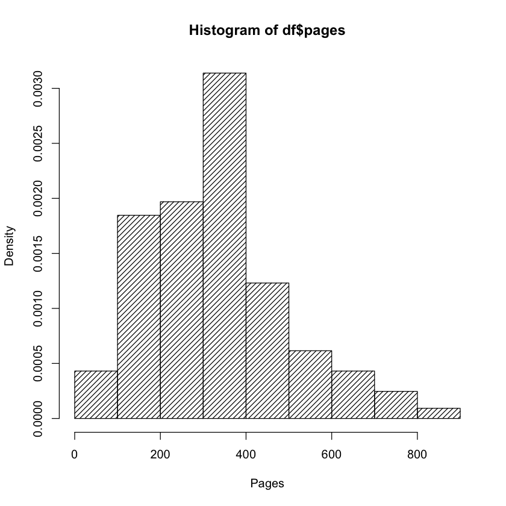

```r
hist(df$pages, density = 20, freq = FALSE, xlab = "Pages", ylab = "Density")
```

There are more books with 300 - 400 pages and very little books with 800 and more pages

#### Use the `plot()` function to produce a scatterplot of `aprice` ($y$) against `lprice` ($x$). What do you notice about this plot?

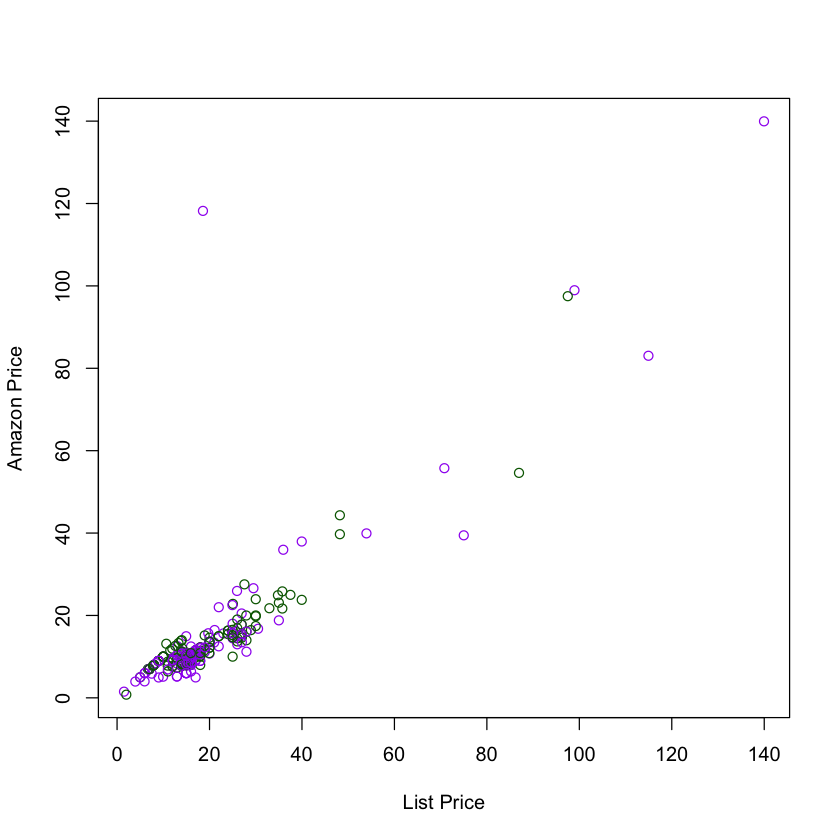

```r
plot(df$lprice, df$aprice, xlab = "List Price", ylab = "Amazon Price", col = c('purple', 'dark green'))
```

#### Use the `boxplot()` function to produce a boxplot of `pages` conditioned on `cover`. Interpret this plot.

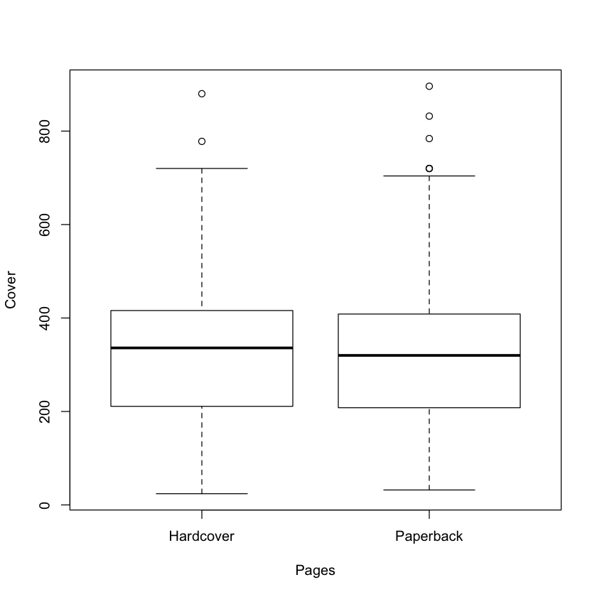

```r
boxplot(df$pages ~ df$cover, xlab = "Pages", ylab = "Cover")
```

Note another way to read data from the web...

```r
### Reading data from the web...
read.table("http://www.stats.ox.ac.uk/pub/datasets/csb/ch11b.dat")
```

| V1 | V2 | V3 | V4 | V5 |
| --- | --- | --- | --- | --- |
| 1 | 307 | 930 | 36.58 | 0 |
| 2 | 307 | 940 | 36.73 | 0 |
| 3 | 307 | 950 | 36.93 | 0 |
| 4 | 307 | 1000 | 37.15 | 0 |
| 5 | 307 | 1010 | 37.23 | 0 |
| 6 | 307 | 1020 | 37.24 | 0 |
| 7 | 307 | 1030 | 37.24 | 0 |
| 8 | 307 | 1040 | 36.90 | 0 |
| 9 | 307 | 1050 | 36.95 | 0 |
| 10 | 307 | 1100 | 36.89 | 0 |
| 11 | 307 | 1110 | 36.95 | 0 |
| 12 | 307 | 1120 | 37.00 | 0 |
| 13 | 307 | 1130 | 36.90 | 0 |
| 14 | 307 | 1140 | 36.99 | 0 |
| 15 | 307 | 1150 | 36.99 | 0 |
| 16 | 307 | 1200 | 37.01 | 0 |
| 17 | 307 | 1210 | 37.04 | 0 |
| 18 | 307 | 1220 | 37.04 | 0 |
| 19 | 307 | 1230 | 37.14 | 0 |
| 20 | 307 | 1240 | 37.07 | 0 |
| 21 | 307 | 1250 | 36.98 | 0 |
| 22 | 307 | 1300 | 37.01 | 0 |
| 23 | 307 | 1310 | 36.97 | 0 |
| 24 | 307 | 1320 | 36.97 | 0 |
| 25 | 307 | 1330 | 37.12 | 0 |
| 26 | 307 | 1340 | 37.13 | 0 |
| 27 | 307 | 1350 | 37.14 | 0 |
| 28 | 307 | 1400 | 37.15 | 0 |
| 29 | 307 | 1410 | 37.17 | 0 |
| 30 | 307 | 1420 | 37.12 | 0 |
| ... | ... | ... | ... | ... |
| 71 | 307 | 2110 | 37.95 | 1 |
| 72 | 307 | 2120 | 37.95 | 1 |
| 73 | 307 | 2130 | 37.76 | 1 |
| 74 | 307 | 2140 | 37.60 | 1 |
| 75 | 307 | 2150 | 37.89 | 1 |
| 76 | 307 | 2200 | 37.86 | 1 |
| 77 | 307 | 2210 | 37.71 | 1 |
| 78 | 307 | 2220 | 37.78 | 1 |
| 79 | 307 | 2230 | 37.82 | 1 |
| 80 | 307 | 2240 | 37.76 | 1 |
| 81 | 307 | 2250 | 37.81 | 1 |
| 82 | 307 | 2300 | 37.84 | 1 |
| 83 | 307 | 2310 | 38.01 | 1 |
| 84 | 307 | 2320 | 38.10 | 1 |
| 85 | 307 | 2330 | 38.15 | 1 |
| 86 | 307 | 2340 | 37.92 | 1 |
| 87 | 307 | 2350 | 37.64 | 1 |
| 88 | 308 | 0 | 37.70 | 1 |
| 89 | 308 | 10 | 37.46 | 1 |
| 90 | 308 | 20 | 37.41 | 1 |
| 91 | 308 | 30 | 37.46 | 1 |
| 92 | 308 | 40 | 37.56 | 1 |
| 93 | 308 | 50 | 37.55 | 1 |
| 94 | 308 | 100 | 37.75 | 1 |
| 95 | 308 | 110 | 37.76 | 1 |
| 96 | 308 | 120 | 37.73 | 1 |
| 97 | 308 | 130 | 37.77 | 1 |
| 98 | 308 | 140 | 38.01 | 1 |
| 99 | 308 | 150 | 38.04 | 1 |
| 100 | 308 | 200 | 38.07 | 1 |